# Test+a+Perceptual+Phenomenon+zh (1)

### 统计学：检验心理学现象

在下方单元格中回答问题并执行相关代码，你可以 参考项目指导 并在正式提交前查看 [项目要求](https://review.udacity.com/#!/rubrics/305/view)。提交时请将 Jupyter notebook 导出成 HTML 或者 PDF 进行提交（File -> Download As）。

背景信息

在一个Stroop （斯特鲁普）任务中，参与者得到了一列文字，每个文字都用一种油墨颜色展示。参与者的任务是将文字的打印颜色大声说出来。这项任务有两个条件：一致文字条件，和不一致文字条件。在一致文字条件中，显示的文字是与它们的打印颜色匹配的颜色词，如“红色”、“蓝色”。在不一致文字条件中，显示的文字是与它们的打印颜色不匹配的颜色词，如“紫色”、“橙色”。在每个情况中，我们将计量说出同等大小的列表中的墨色名称的时间。每位参与者必须全部完成并记录每种条件下使用的时间。

调查问题

作为一般说明，请确保记录你在创建项目时使用或参考的任何资源。作为项目提交的一部分，你将需要报告信息来源。

(1) 我们的自变量是什么？因变量是什么？

自变量:参加斯特鲁普实验的任务的两种不同条件，即文字和颜色是否一致

因变量:参与者完成记录下的在同等大小的列表中的(即同等数量的)墨色名称的时间

(2) 此任务的适当假设集是什么？你需要以文字和数学符号方式对假设集中的零假设和对立假设加以说明，并对数学符号进行定义。你想执行什么类型的统计检验？为你的选择提供正当理由（比如，为何该实验满足你所选统计检验的前置条件）。

任务的假设集：  
假设当文字条件一致时，总体均值为$\mu_{con}$  
假设当文字条件不一致时，总体均值为$\mu_{incon}$

零假设  
$H_0$ 文字颜色不一致， $\mu_{con}$ = $\mu_{incon}$，即人的反应时间不会因为字体内容和字体颜色是否相同而发生改变  
对立假设  
$H_1$ 文字颜色不一致，$\mu_{con}$ < $\mu_{incon}$，即人的反应时间在字体内容和字体颜色不一致的情况下会变长

我想执行t相关配对检验，理由是：  
T相关配对检验适用于数据量较小（<30），总体标准差未知，两组数据是相关样本（这里是文字颜色一致和不一致时），字体内容与颜色内容是否相同对反应时间的影响相比，即关注于两组相关数据的差值的情况

我想采用单尾检验，且采用$\alpha$=0.05  
由于预估$\mu_{con}$ < $\mu_{incon}$具有方向性，所以采用单尾检验

现在轮到你自行尝试 Stroop 任务了。前往[此链接](https://faculty.washington.edu/chudler/java/ready.html)，其中包含一个基于 Java 的小程序，专门用于执行 Stroop 任务。记录你收到的任务时间（你无需将时间提交到网站）。现在[下载此数据集](https://s3.cn-north-1.amazonaws.com.cn/static-documents/nd002/stroopdata.csv)，其中包含一些任务参与者的结果。数据集的每行包含一名参与者的表现，第一个数字代表他们的一致任务结果，第二个数字代表不一致任务结果。

(3) 报告关于此数据集的一些描述性统计。包含至少一个集中趋势测量和至少一个变异测量。

集中趋势测量包括：众数，中位数和均数  
对于此数据集，没有众数，工具为google spreadsheets,利用排序和average函数,计算了中位数和均数作为集中趋势量,在此用pandas只是读取了excel中的数据

```python
import pandas as pd
def readxls():
    data= pd.read_excel("file:D:\\dataAnalysis\\project1\\data_analysis.xlsx", keep_default_na=False, header=None)
    print(data.iloc[28:33,:3])

readxls();
```

```
              0      1      2
28
29   统计数据(集中趋势)
30                 中位数     均值
31    Congruent  14.36  14.05
32  Incongruent  21.02  22.02
```

常用的变异测量包括：全距，四分位距，方差和标准差，工具为google spreadsheets,利用average,平方和sqrt，计算了变异量和标准差，在此用pandas只是读取了excel中的数据

```python
import pandas as pd
def readxls():
    data= pd.read_excel("file:D:\\dataAnalysis\\project1\\data_analysis.xlsx", keep_default_na=False, header=None)
    print(data.iloc[35:39,:5])

readxls();
```

[output not shown]

(4) 提供显示样本数据分布的一个或两个可视化。用一两句话说明你从图中观察到的结果。

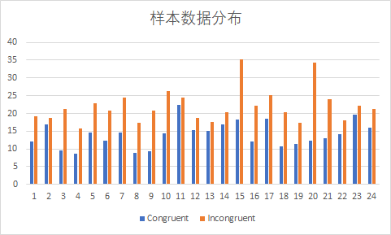

(5) 现在，执行统计测试并报告你的结果。你的置信水平和关键统计值是多少？你是否成功拒绝零假设？对试验任务得出一个结论。结果是否与你的期望一致？

单位检验中的右尾检验，采用显著水平$\alpha$=0.05 为了检验真实均值差为零的零假设，过程如下 如下:
1.计算每对两个观测值之间的差$d_i$ = $y_i-x_i$
2.计算差的均值d
3.计算差的标准偏差$s_d$，并使用此标准偏差来计算平均差标准误差:$$SE(d)=\frac {s_d}{\sqrt n}$$
4.计算t统计量:$$T=\frac {d}{SE(d)}$$ 在零假设下，该统计数据遵循具有n − 1个自由度的t分布
5.使用t分布表将T的值与$t_{n-1}$分布进行比较,给出配对t检验的p值

利用google speedsheets工具，计算出结果，在此用pandas只是读取了excel中的数据：

```python
import pandas as pd
def readxls():
    data= pd.read_excel("file:D:\\dataAnalysis\\project1\\data_analysis.xlsx", keep_default_na=False, header=None)
    print(data.iloc[41:44,:5])

readxls();
```

```
             0   1        2                3               4
41    样本差值统计数据
42               N     Mean  Stand Deviation  Std Error Mean
43  Difference  24  7.96479          4.86483        0.993029
```

实验结果：

```python
import pandas as pd
def readxls():
    data= pd.read_excel("file:D:\\dataAnalysis\\project1\\data_analysis.xlsx", keep_default_na=False, header=None)
    print(data.iloc[46:49,:5])

readxls();
```

```
             0      1   2                 3        4
46      样本实验结果
47                  t  df       p(1-tailed)     Mean
48  Difference  8.021  23  <0.0005(远小于0.05)  7.96479
```

根据右尾判断的条件，t>0并且p<$\alpha$ 则拒绝零假设，有统计显著，也就是接受备选假设，特鲁普效应存在